# [Final Project]

## Jaelynn’s Code

```r
# code for part a
file_path <- "datasets/wages_train.csv"
file_path <- "datasets/wages_test.csv"
# Read CSV using read.csv
wages_train <- read.csv(file_path)
wages_test <- read.csv(file_path)
# Display the first few rows of the data
head(wages_train)
```

|  | year | union | ethnicity | married | health | industry | occupation | residence | lwage | lschool | lexper |
| --- | --- | --- | --- | --- | --- | --- | --- | --- | --- | --- | --- |
| 1 | 2018 | no | other | no | no | Business_and_Repair_Service | Managers, Officials_and_Proprietors | north_east | 11.12639 | 2.639057 | 2.197225 |
| 2 | 2013 | no | other | no | no | Trade | Service_Workers | north_east | 10.91929 | 2.302585 | 1.609438 |
| 3 | 2011 | no | other | no | no | Trade | Sales_Workers | north_east | 11.19449 | 2.564949 | 1.098612 |
| 4 | 2013 | no | other | no | no | Trade | Managers, Officials_and_Proprietors | north_east | 11.64712 | 2.564949 | 1.609438 |
| 5 | 2018 | no | other | yes | no | Trade | Managers, Officials_and_Proprietors | north_east | 11.87188 | 2.564949 | 2.302585 |
| 6 | 2014 | no | other | no | no | Trade | Laborers_and_farmers | north_east | 10.99709 | 2.397895 | 1.791759 |

```r
head(wages_test)
```

|  | year | union | ethnicity | married | health | industry | occupation | residence | lwage | lschool | lexper |
| --- | --- | --- | --- | --- | --- | --- | --- | --- | --- | --- | --- |
| 1 | 2018 | no | other | no | no | Business_and_Repair_Service | Managers, Officials_and_Proprietors | north_east | 11.12639 | 2.639057 | 2.197225 |
| 2 | 2013 | no | other | no | no | Trade | Service_Workers | north_east | 10.91929 | 2.302585 | 1.609438 |
| 3 | 2011 | no | other | no | no | Trade | Sales_Workers | north_east | 11.19449 | 2.564949 | 1.098612 |
| 4 | 2013 | no | other | no | no | Trade | Managers, Officials_and_Proprietors | north_east | 11.64712 | 2.564949 | 1.609438 |
| 5 | 2018 | no | other | yes | no | Trade | Managers, Officials_and_Proprietors | north_east | 11.87188 | 2.564949 | 2.302585 |
| 6 | 2014 | no | other | no | no | Trade | Laborers_and_farmers | north_east | 10.99709 | 2.397895 | 1.791759 |

```r
getwd()
```

```
## [1] "/Users/Dylan/Library/CloudStorage/OneDrive-ChapmanUniversity/MGSC_310"
```

1b)A factor variable is a categorical variable!For example in this data set you may want to convert occupation, residence, ethnicity,industry, ect…

```r
# code for part b
```

1c)#The association is weakest in construction and strongest in the “other” category. #revist this tbh

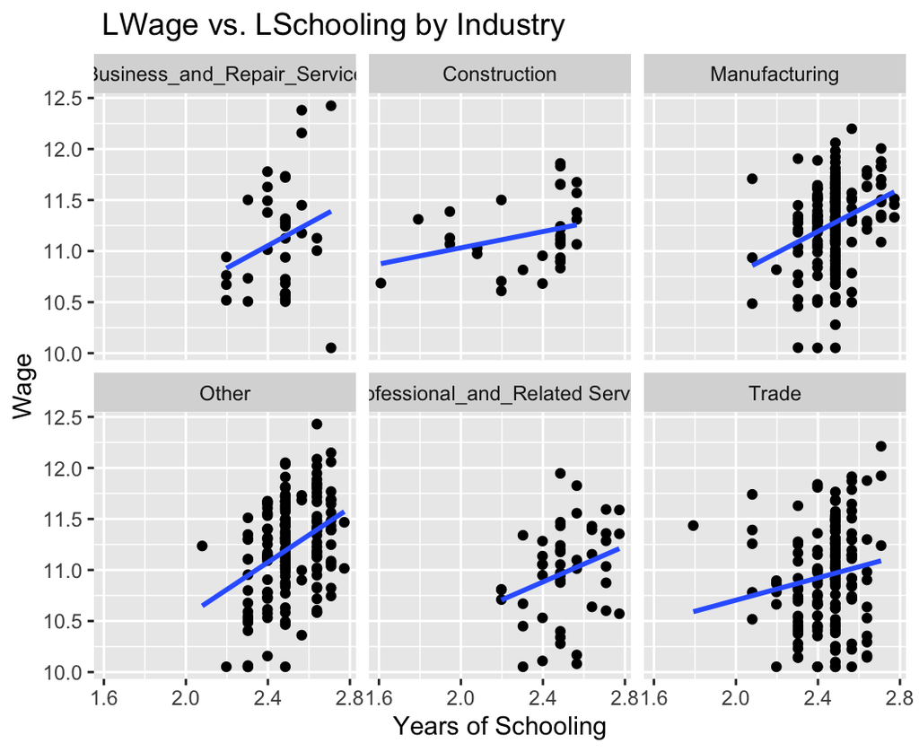

```r
# code for part c

  ggplot(data = wages_train, aes(x = lschool, y = lwage)) +
    geom_point() +
    geom_smooth(method = "lm", se = FALSE) +
    facet_wrap(~ industry) +
    labs(title = " LWage vs. LSchooling by Industry",
         x = "Years of Schooling",
         y = "Wage")
```

1d)

```r
# code for part d
lm_mod1 <- lm(lwage ~ year + union + health + industry + occupation + lschool +lexper,
            data = wages_train)
summary(lm_mod1)
```

```
##
## Call:
## lm(formula = lwage ~ year + union + health + industry + occupation +
##     lschool + lexper, data = wages_train)
##
## Residuals:
##      Min       1Q   Median       3Q      Max
## -1.30564 -0.27044  0.04179  0.26188  1.02690
##
## Coefficients:
##                                                 Estimate Std. Error
## (Intercept)                                   -58.982679  29.567831
## year                                            0.033579   0.014803
## unionyes                                        0.178489   0.039157
## healthyes                                       0.053998   0.130876
## industryConstruction                            0.117600   0.100408
## industryManufacturing                           0.070324   0.076165
## industryOther                                   0.041209   0.076709
## industryProfessional_and_Related Service       -0.201425   0.091160
## industryTrade                                  -0.127746   0.076854
## occupationCraftsmen, Foremen_and_kindred        0.090813   0.063114
## occupationFarm_Laborers_and_Foreman            -0.237540   0.135743
## occupationLaborers_and_farmers                 -0.004753   0.073588
## occupationManagers, Officials_and_Proprietors   0.159861   0.073289
## occupationOperatives_and_kindred                0.087504   0.064914
## occupationProfessional, Technical_and_kindred   0.228584   0.068758
## occupationSales_Workers                        -0.002496   0.083938
## occupationService_Workers                      -0.029380   0.068389
## lschool                                         0.851337   0.136046
## lexper                                          0.141287   0.085490
##                                               t value       Pr(>|t|)
## (Intercept)                                    -1.995        0.04651
## year                                            2.268        0.02366
## unionyes                                        4.558 0.000006247197
## healthyes                                       0.413        0.68005
## industryConstruction                            1.171        0.24198
## industryManufacturing                           0.923        0.35622
## industryOther                                   0.537        0.59132
## industryProfessional_and_Related Service       -2.210        0.02751
## industryTrade                                  -1.662        0.09700
```

[output cut: 21 more lines]

```
## occupationFarm_Laborers_and_Foreman           .
## occupationLaborers_and_farmers
## occupationManagers, Officials_and_Proprietors *
## occupationOperatives_and_kindred
## occupationProfessional, Technical_and_kindred ***
## occupationSales_Workers
## occupationService_Workers
## lschool                                       ***
## lexper                                        .
## ---
## Signif. codes:  0 '***' 0.001 '**' 0.01 '*' 0.05 '.' 0.1 ' ' 1
##
## Residual standard error: 0.4037 on 603 degrees of freedom
## Multiple R-squared:  0.2865, Adjusted R-squared:  0.2652
## F-statistic: 13.45 on 18 and 603 DF,  p-value: < 0.00000000000000022
```

1e) For Lschool we can find a strong pattern in years of schooling and lwage. As the unit or year of schooling increases by 1 there is a positive increase in wage by 0.85 or 85%. We can also see another positive association between wage and expereince. As the unit of experience increases by 1 there is an increase in wage by 0.14 or 14%.

```r
# code for part e
```

1f)Our variable lexper holds a p-value of 0.09892. Typically we would want our p-value to be lower than the value of 0.05.This shows statistical insignificance and explains that this variable is not super strong and could possibly be due to chance in out model.So from this we can gather the idea that although there is a positive relationship between wage and experience, it is not a strong relationship.We can compare this relationship to schooling and wage where our p-value is more desirable. Based off of this i would put more resources or intrest in having more years of schooling than experience.

```r
# code for part f
```

1g)

```r
# code for part g

#library(dplyr)
wages_train <- wages_train %>%
  mutate(wage = exp(lwage),
         school = exp(lschool),
         exper = exp(lexper))

lm_mod2 <- lm(wage ~ school + exper + union, data = wages_train)
summary(lm_mod2)
```

```
##
## Call:
## lm(formula = wage ~ school + exper + union, data = wages_train)
##
## Residuals:
##    Min     1Q Median     3Q    Max
## -77313 -22397  -2346  17695 157507
##
## Coefficients:
##             Estimate Std. Error t value             Pr(>|t|)
## (Intercept) -52483.4    11015.5  -4.765  0.00000236192055514 ***
## school        8019.4      798.3  10.046 < 0.0000000000000002 ***
## exper         4088.2      495.6   8.248  0.00000000000000097 ***
## unionyes     12477.0     2870.0   4.347  0.00001610859137248 ***
## ---
## Signif. codes:  0 '***' 0.001 '**' 0.01 '*' 0.05 '.' 0.1 ' ' 1
##
## Residual standard error: 31610 on 618 degrees of freedom
## Multiple R-squared:  0.2054, Adjusted R-squared:  0.2016
## F-statistic: 53.26 on 3 and 618 DF,  p-value: < 0.00000000000000022
```

1h)below we can observe that our estimate of unionyes is 12477. This reveals that being apart of a union adds 12477 units (usd) to wage as opposed to not being a union member! We can further observe that this is plausible because of our small p-value which proves statistical significance. This just means that our model is not based off of chance and this relationsip of being a union member and having higher wages than a non-union member is real.

```r
# code for part h
```

## Question 2

```r
# code for 2a
wages_sub <- wages_train %>% select(lwage, union, married, industry, occupation, lexper, residence)
ridge_mod <- cv.glmnet(x = as.matrix(wages_sub %>% select(-lwage)),
                       y = wages_sub$lwage,
                       alpha = 0)  #note alpha = 0 sets ridge!

print(ridge_mod)
```

```
##
## Call:  cv.glmnet(x = as.matrix(wages_sub %>% select(-lwage)), y = wages_sub$lwage,      alpha = 0)
##
## Measure: Mean-Squared Error
##
##     Lambda Index Measure      SE Nonzero
## min   0.01   100  0.2094 0.01299
## 1se 117.50     1  0.2220 0.01371     100
```

```r
summary(ridge_mod)
```

```
##            Length Class  Mode
## lambda     100    -none- numeric
## cvm        100    -none- numeric
## cvsd       100    -none- numeric
## cvup       100    -none- numeric
## cvlo       100    -none- numeric
## nzero        1    -none- numeric
## call         4    -none- call
## name         1    -none- character
## glmnet.fit  12    elnet  list
## lambda.min   1    -none- numeric
## lambda.1se   1    -none- numeric
## index        2    -none- numeric
```

```r
#test no
wages_sub <- wages_test %>% select(lwage, union, married, industry, occupation, lexper, residence)
ridge_mod2 <- cv.glmnet(x = as.matrix(wages_sub %>% select(-lwage)),
                       y = wages_sub$lwage,
                       alpha = 0)  #note alpha = 0 sets ridge!
print(ridge_mod2)
```

```
##
## Call:  cv.glmnet(x = as.matrix(wages_sub %>% select(-lwage)), y = wages_sub$lwage,      alpha = 0)
##
## Measure: Mean-Squared Error
##
##     Lambda Index Measure       SE Nonzero
## min 0.0118   100  0.2087 0.006131
## 1se 0.9312    53  0.2145 0.007619
```

```r
summary(ridge_mod2)
```

```
##            Length Class  Mode
## lambda     100    -none- numeric
## cvm        100    -none- numeric
## cvsd       100    -none- numeric
## cvup       100    -none- numeric
## cvlo       100    -none- numeric
## nzero        1    -none- numeric
## call         4    -none- call
## name         1    -none- character
## glmnet.fit  12    elnet  list
## lambda.min   1    -none- numeric
## lambda.1se   1    -none- numeric
## index        2    -none- numeric
```

```r
# code for 2b
wages_sub <- wages_train %>% select(lwage, union, married, industry, occupation, lexper, residence)
lasso_mod <- cv.glmnet(x = as.matrix(wages_sub %>% select(-lwage)),
                       y = wages_sub$lwage,
                       alpha = 1)  #note alpha = 1 sets lasso!

print(lasso_mod)
```

```
##
## Call:  cv.glmnet(x = as.matrix(wages_sub %>% select(-lwage)), y = wages_sub$lwage,      alpha = 1)
##
## Measure: Mean-Squared Error
##
##      Lambda Index Measure       SE Nonzero
## min 0.00077    55  0.2100 0.011062       1
## 1se 0.09755     3  0.2194 0.009443       1
```

```r
summary(lasso_mod)
```

```
##            Length Class  Mode
## lambda     55     -none- numeric
## cvm        55     -none- numeric
## cvsd       55     -none- numeric
## cvup       55     -none- numeric
## cvlo       55     -none- numeric
## nzero      55     -none- numeric
## call        4     -none- call
## name        1     -none- character
## glmnet.fit 12     elnet  list
## lambda.min  1     -none- numeric
## lambda.1se  1     -none- numeric
## index       2     -none- numeric
```

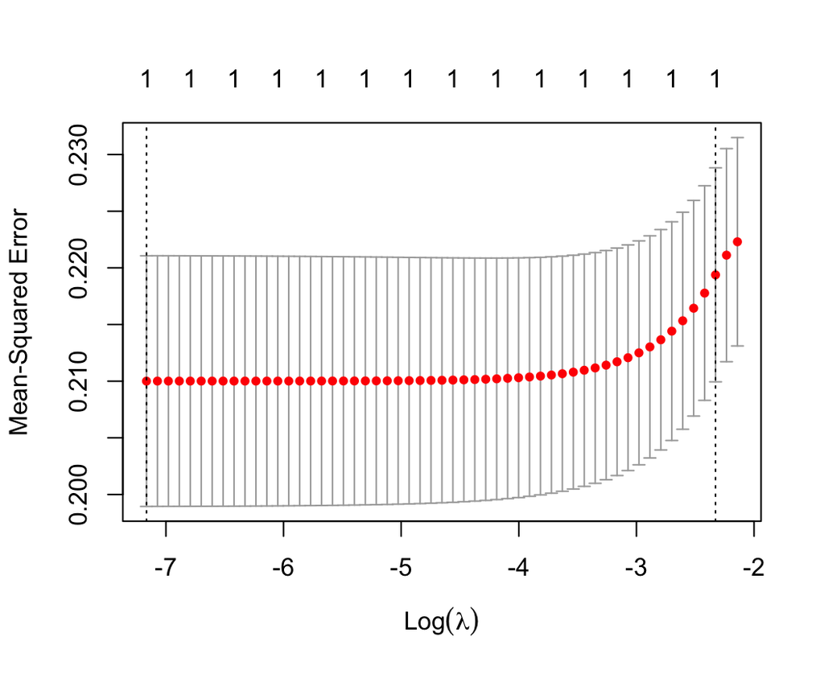

```r
# code for 2c
plot(lasso_mod)
```

```r
# code for 2d
```

2e)K-fold cross validation takes the concept of taking our observations for resampling and then leaving one out for testing the data. This process is repeated until all of our folds ( equal division of the data) have be used.For the above models we used cv.glment which aided us in dividing our data (specific varaibles union, married, industry, occupation, lexper, residence) into k-folds for sampling.

```r
# code for 2e
```

## Question 3

3a)

```r
# code for 3a

file_path <- "datasets/credit_train.csv"
file_path <- "datasets/credit_test.csv"

# Read CSV using read.csv
credit_train <- read.csv(file_path)
credit_test <- read.csv(file_path)
```

3b)

```r
# code for 3b
glimpse(credit_train)
```

```
## Rows: 12,936
## Columns: 9
## $ default           <int> 0, 0, 0, 0, 0, 0, 0, 0, 0, 0, 0, 0, 0, 0, …
## $ utilization       <dbl> 0.754463648, 0.644225962, 0.019656581, 0.6…
## $ age               <int> 39, 30, 76, 25, 69, 42, 75, 70, 70, 29, 46…
## $ debt_ratio        <dbl> 0.209940017, 0.309476210, 477.000000000, 0…
## $ income            <dbl> 3500.000, 2500.000, 0.000, 333.000, 2500.0…
## $ open_credit_lines <int> 8, 5, 6, 2, 17, 7, 1, 12, 21, 1, 6, 6, 4, …
## $ real_estate_loan  <int> 0, 0, 1, 0, 0, 0, 1, 1, 1, 0, 1, 0, 0, 1, …
## $ dependents        <int> 0, 0, 0, 0, 1, 0, 1, 2, 0, 0, 2, 2, 0, 0, …
## $ ever_past_due     <int> 0, 0, 0, 0, 0, 1, 1, 0, 0, 0, 0, 0, 0, 0, …
```

```r
glimpse(credit_test)
```

```
## Rows: 12,936
## Columns: 9
## $ default           <int> 0, 0, 0, 0, 0, 0, 0, 0, 0, 0, 0, 0, 0, 0, …
## $ utilization       <dbl> 0.754463648, 0.644225962, 0.019656581, 0.6…
## $ age               <int> 39, 30, 76, 25, 69, 42, 75, 70, 70, 29, 46…
## $ debt_ratio        <dbl> 0.209940017, 0.309476210, 477.000000000, 0…
## $ income            <dbl> 3500.000, 2500.000, 0.000, 333.000, 2500.0…
## $ open_credit_lines <int> 8, 5, 6, 2, 17, 7, 1, 12, 21, 1, 6, 6, 4, …
## $ real_estate_loan  <int> 0, 0, 1, 0, 0, 0, 1, 1, 1, 0, 1, 0, 0, 1, …
## $ dependents        <int> 0, 0, 0, 0, 1, 0, 1, 2, 0, 0, 2, 2, 0, 0, …
## $ ever_past_due     <int> 0, 0, 0, 0, 0, 1, 1, 0, 0, 0, 0, 0, 0, 0, …
```

```r
# code for part 3c
mod1 <- lm(default ~ income + real_estate_loan + age + ever_past_due,
           data = credit_train)
summary(mod1)
```

```
##
## Call:
## lm(formula = default ~ income + real_estate_loan + age + ever_past_due,
##     data = credit_train)
##
## Residuals:
##      Min       1Q   Median       3Q      Max
## -0.26721 -0.06815 -0.04069 -0.02176  1.01306
##
## Coefficients:
##                       Estimate    Std. Error t value
## (Intercept)       0.1394086148  0.0087702709  15.896
## income           -0.0000021115  0.0000006703  -3.150
## real_estate_loan -0.0175173259  0.0046142966  -3.796
## age              -0.0013995205  0.0001485582  -9.421
## ever_past_due     0.1617609502  0.0058746098  27.536
##                              Pr(>|t|)
## (Intercept)      < 0.0000000000000002 ***
## income                       0.001637 **
## real_estate_loan             0.000148 ***
## age              < 0.0000000000000002 ***
## ever_past_due    < 0.0000000000000002 ***
## ---
## Signif. codes:  0 '***' 0.001 '**' 0.01 '*' 0.05 '.' 0.1 ' ' 1
##
## Residual standard error: 0.2444 on 12931 degrees of freedom
## Multiple R-squared:  0.06837,    Adjusted R-squared:  0.06809
## F-statistic: 237.3 on 4 and 12931 DF,  p-value: < 0.00000000000000022
```

```r
# code for 3d
```

3e) Yes, I would not find that real_estate_loan has a causal impact on default. Our coefficient magnitude would assume somewhat differently, we can make a great assumption that there is somewhat of a casual relationship.This model reveals that there is a strong relationship between the two variables but there is more that goes into causal impact. I would say that forming causal relationships when predicting default behavior is important.This would require further expertise in deciding if two variables are truly casual or not, but for prediction of default the magnitude of each relationship reveals a lot.The large point of making these predictions is to find relationships between each variables and understand how they impact one another.

## Question 1

```r
media <- read_csv("datasets/sentimentdataset.csv")

media_clean <- media %>%
  mutate(
    Timestamp = as.character(Timestamp),
    Timestamp = as.POSIXct(Timestamp, format = "%Y-%m-%d %H:%M:%S", tz = "UTC"),
    Day_Of_Week = wday(Timestamp, label = TRUE, abbr = FALSE),
    Viral = ifelse(Likes >
                     50, 1, 0),
    Day_Of_Week_factor = as.factor(Day_Of_Week),
    Year_factor = as.factor(Year),
    Month_factor = as.factor(Month)
    )

#Split dataset into Train and Test Sets
media_split <- initial_split(media_clean, prop = 0.75)
media_train <- training(media_split)
media_test <- testing(media_split)


#Fit a logistic regression model to predict whether a movie is viral using 'Day_Of_Week_factor', 'Year_factor', 'Month_factor', and 'Hour' as predictors.
media_logit1 <-  glm(Viral ~ Year_factor + Month_factor + Day_Of_Week_factor + Hour,
                     family=binomial,
                     data = media_train)

summary(media_logit1)
```

```
##
## Call:
## glm(formula = Viral ~ Year_factor + Month_factor + Day_Of_Week_factor +
##     Hour, family = binomial, data = media_train)
##
## Coefficients:
##                        Estimate Std. Error z value Pr(>|z|)
## (Intercept)            14.28188 2399.54485   0.006 0.995251
## Year_factor2011       -33.15456 3393.46875  -0.010 0.992205
## Year_factor2012       -32.12533 2769.90609  -0.012 0.990746
## Year_factor2013       -32.47255 2745.21566  -0.012 0.990562
## Year_factor2014       -32.61710 2663.19611  -0.012 0.990228
## Year_factor2015       -16.46032 2399.54481  -0.007 0.994527
## Year_factor2016       -17.10135 2399.54478  -0.007 0.994314
## Year_factor2017       -17.62571 2399.54479  -0.007 0.994139
## Year_factor2018       -17.20939 2399.54477  -0.007 0.994278
## Year_factor2019       -17.33316 2399.54476  -0.007 0.994237
## Year_factor2020       -17.47244 2399.54477  -0.007 0.994190
## Year_factor2021       -17.15796 2399.54477  -0.007 0.994295
## Year_factor2022       -17.85913 2399.54479  -0.007 0.994062
## Year_factor2023       -17.56283 2399.54476  -0.007 0.994160
## Month_factor2          -0.75224    0.55953  -1.344 0.178817
## Month_factor3           0.20406    0.54207   0.376 0.706589
## Month_factor4           0.29092    0.55524   0.524 0.600307
## Month_factor5          -0.14564    0.56584  -0.257 0.796876
## Month_factor6           0.96519    0.45387   2.127 0.033456 *
## Month_factor7           0.59843    0.47776   1.253 0.210363
## Month_factor8          -0.05552    0.48465  -0.115 0.908794
## Month_factor9          -0.41831    0.50515  -0.828 0.407616
## Month_factor10         -0.81308    0.70791  -1.149 0.250734
## Month_factor11          0.11849    0.56240   0.211 0.833136
## Month_factor12         -0.93630    0.68590  -1.365 0.172233
## Day_Of_Week_factor.L    0.03739    0.28584   0.131 0.895942
## Day_Of_Week_factor.Q    0.18117    0.28442   0.637 0.524139
## Day_Of_Week_factor.C    0.06792    0.29497   0.230 0.817891
## Day_Of_Week_factor^4    0.41741    0.31310   1.333 0.182488
## Day_Of_Week_factor^5   -0.16406    0.30344  -0.541 0.588727
## Day_Of_Week_factor^6    0.08985    0.30745   0.292 0.770101
## Hour                    0.11804    0.03036   3.888 0.000101 ***
## ---
## Signif. codes:  0 '***' 0.001 '**' 0.01 '*' 0.05 '.' 0.1 ' ' 1
##
## (Dispersion parameter for binomial family taken to be 1)
##
##     Null deviance: 591.47  on 548  degrees of freedom
## Residual deviance: 523.51  on 517  degrees of freedom
## AIC: 587.51
##
## Number of Fisher Scoring iterations: 15
```

```r
#Print summary
summary(media_logit1)
```

```
##
## Call:
## glm(formula = Viral ~ Year_factor + Month_factor + Day_Of_Week_factor +
##     Hour, family = binomial, data = media_train)
##
## Coefficients:
##                        Estimate Std. Error z value Pr(>|z|)
## (Intercept)            14.28188 2399.54485   0.006 0.995251
## Year_factor2011       -33.15456 3393.46875  -0.010 0.992205
## Year_factor2012       -32.12533 2769.90609  -0.012 0.990746
## Year_factor2013       -32.47255 2745.21566  -0.012 0.990562
## Year_factor2014       -32.61710 2663.19611  -0.012 0.990228
## Year_factor2015       -16.46032 2399.54481  -0.007 0.994527
## Year_factor2016       -17.10135 2399.54478  -0.007 0.994314
## Year_factor2017       -17.62571 2399.54479  -0.007 0.994139
## Year_factor2018       -17.20939 2399.54477  -0.007 0.994278
## Year_factor2019       -17.33316 2399.54476  -0.007 0.994237
## Year_factor2020       -17.47244 2399.54477  -0.007 0.994190
## Year_factor2021       -17.15796 2399.54477  -0.007 0.994295
## Year_factor2022       -17.85913 2399.54479  -0.007 0.994062
## Year_factor2023       -17.56283 2399.54476  -0.007 0.994160
## Month_factor2          -0.75224    0.55953  -1.344 0.178817
## Month_factor3           0.20406    0.54207   0.376 0.706589
## Month_factor4           0.29092    0.55524   0.524 0.600307
## Month_factor5          -0.14564    0.56584  -0.257 0.796876
## Month_factor6           0.96519    0.45387   2.127 0.033456 *
## Month_factor7           0.59843    0.47776   1.253 0.210363
## Month_factor8          -0.05552    0.48465  -0.115 0.908794
## Month_factor9          -0.41831    0.50515  -0.828 0.407616
## Month_factor10         -0.81308    0.70791  -1.149 0.250734
## Month_factor11          0.11849    0.56240   0.211 0.833136
## Month_factor12         -0.93630    0.68590  -1.365 0.172233
## Day_Of_Week_factor.L    0.03739    0.28584   0.131 0.895942
## Day_Of_Week_factor.Q    0.18117    0.28442   0.637 0.524139
## Day_Of_Week_factor.C    0.06792    0.29497   0.230 0.817891
## Day_Of_Week_factor^4    0.41741    0.31310   1.333 0.182488
## Day_Of_Week_factor^5   -0.16406    0.30344  -0.541 0.588727
## Day_Of_Week_factor^6    0.08985    0.30745   0.292 0.770101
## Hour                    0.11804    0.03036   3.888 0.000101 ***
## ---
## Signif. codes:  0 '***' 0.001 '**' 0.01 '*' 0.05 '.' 0.1 ' ' 1
##
## (Dispersion parameter for binomial family taken to be 1)
##
##     Null deviance: 591.47  on 548  degrees of freedom
## Residual deviance: 523.51  on 517  degrees of freedom
## AIC: 587.51
##
## Number of Fisher Scoring iterations: 15
```

```r
levels(media_clean$Day_Of_Week_factor)
```

```
## [1] "Sunday"    "Monday"    "Tuesday"   "Wednesday" "Thursday"
## [6] "Friday"    "Saturday"
```

```r
exp_coefs <- exp(coef(media_logit1))
exp(coef(media_logit1)['Month_factor7'])
## Month_factor7
##      1.819262


exp(coef(media_logit1)['Hour'])
```

```
##     Hour
## 1.125293
```

```r
#Score Model on Train and Test Set
scores_train <- predict(media_logit1,
                  type = "response",
                  data = media_train)

scores_test <- predict(media_logit1,
                        type = "response",
                        data = media_test)
```

```r
#Create a results data frame that holds the true class
#the predicted class, the predicted probability of the event



results_train <- tibble(
  `true_class` = as.factor(media_train$Viral),
  `prob_event` =  scores_train,
  `prob_not_event` = 1 - scores_train,
  `pred_class` = as.factor(ifelse(scores_train > 0.4,
                                  "1","0"))
)

results_test <- data.frame(
  `true_class` = as.factor(media_test$Viral),
  `prob_event` =  scores_test,
  `prob_not_event` = 1 - scores_train,
  `pred_class` = as.factor(ifelse(scores_test > 0.4,
                                  "1","0")))
```

```r
#4. Generate a confusion matrix using the results data frame using 0.4 as the cutoff
cm_train <- conf_mat(results_train,
               truth = true_class,
               estimate = pred_class)

print(cm_train)
```

```
##           Truth
## Prediction   0   1
##          0 391  91
##          1  32  35
```

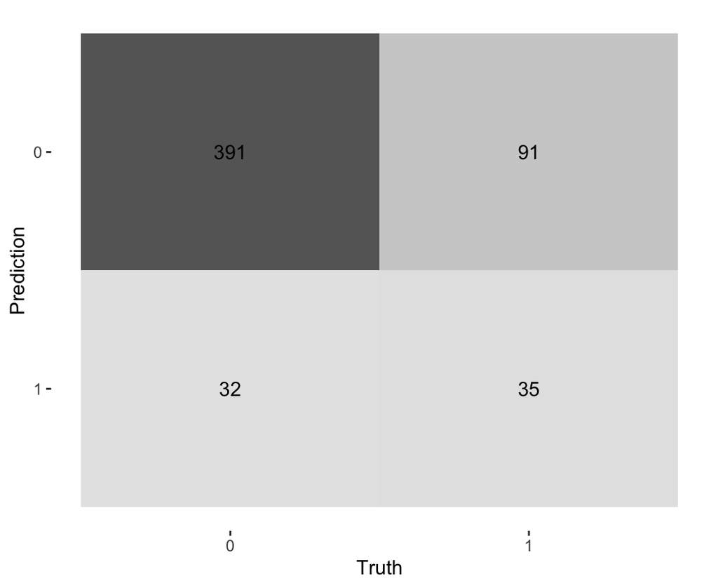

```r
autoplot(cm_train, "heatmap")
```

```r
cm_test <- conf_mat(results_test,
                     truth = true_class,
                     estimate = pred_class)

print(cm_test)
```

```
##           Truth
## Prediction   0   1
##          0 375 107
##          1  57  10
```

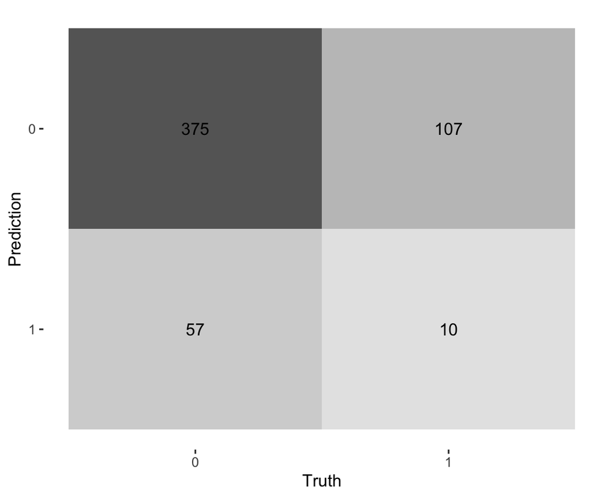

```r
autoplot(cm_test, "heatmap")
```

[output not shown]